# Technical note: Admixed mapping in African Americans for detection of gene-by-environment interactions

Andrey Ziyatdinov et al.

2018-02-06

# Background

Our analysis of 3,3000 African Americans from the COPDGene project aimed to leverage the ancestry information in admixed populations for detection of gene-by-environment. We conducted admixed mapping using inferred local ancestry as genetic variables and smoking status as environmental exposure. We expected increased statistical power in detecting interactions based on our two previous works:

- **Theoretical work:** We proposed to leverage the correlation between local ancestry and hidden unknown causal variants for detection of distant gene-gene interactions in admixed populations (Aschard et al. 2015). By conducting simulations, we confirmed our analytical derivations that the power of such admixed mapping increases with the number of causal variants within local ancestry and the degree of variant differentiation among the ancestral populations.
- **Admixed mapping in COPDGene:** We previously analyzed spirometric lung function phenotypes available in the COPDGene dataset, combining admixture and association mappings to establish a marker on Chromosome 12q14 associated with a reduced lung function (Parker et al. 2014).

# Admixed mapping in discovery dataset (COPDGene)

## Ancestry data processing

**Local ancestry inference:** We inferred local ancestry using the LAMP-LD program (Baran et al. 2012) with 15 HMM states and a window size of 50 SNPs using 99 CEU and 108 YRI unrelated individuals from the 1,000 Genomes project (phase 3). As a result, we obtained estimates of having 0, 1 or 2 African chromosomes at each SNP position and stored in a data matrix $Z_{LAMP}$ (individuals in rows and SNP positions in columns).

**Global ancestry:** We averaged the local ancestry across rows of the data matrix $Z_{LAMP}$ to give the genome-wide proportion of African ancestry. Its values among 3,300 African American COPDGene participants were in the range of 26.3% to 99.8% and with the mean value of 80.3%.

**Long local ancestry:** We estimated local ancestry segments by merging columns of the data matrix $Z_{LAMP}$ with identical values. We next filtered out short ancestry segments of length less than 10,000 bases to mitigate possible artifacts of the inference procedure that might affect further admixed mapping analysis (The LAMP-LD authors 2017). The resulted data matrix $Z$ has 33,043 columns and was used in admixed mapping.

[output not shown]

## Statistical analysis

**Selection bias in COPDGene**: According to the COPDGene study protocol, participants needed to have a smoking history at least 10 pack-years. That means that all participants are ever smokers, who were either current non-smoker or current smoker at the moment of recruitment. Consequently, the effect of the current smoking status was associated with improved lung function (reverse causation phenomenon). Additionally, the dataset was enriched for the patients with COPD.

**Five quantitative traits:** We modeled five spirometric measures of lung function: forced expiratory volume in one second (`FEV1`); forced expiratory volume in one second as a percent of predicted (`FEV1pp`); forced vital capacity (`FVC`); forced vital capacity as a percent of predicted (`FVCpp`); and the ratio of forced expiratory volume in one second to forced vital capacity (`FEV1_FVC`). We did not analyzed the binary outcome of the COPD disease status, due to overall complexity of its modeling at the initial phase of the analysis.

- `FEV1`: forced expiratory volume in one second; measured as the amount of air forcefully exhaled in one second;
- `FEV1pp`: forced expiratory volume in one second as a percent of predicted; calculated using race and gender-specific regression models based on age, age squared and height squared (Hankinson, Odencrantz, and Fedan 1999);
- `FVC`: forced vital capacity (FVC); calculated similarly to `FEV1`, but the maximal exhalation lasts 6 seconds or greater;
- `FVCpp`: forced vital capacity as a percent of predicted; calculated (similary to `FEV1pp`) using race and gender-specific regression models based on age, age squared and height squared (Hankinson, Odencrantz, and Fedan 1999);
- `FEV1_FVC`: the ratio of forced expiratory volume in one second to forced vital capacity; the ratio determines the airflow obstruction when `FVCpp` values are below 0.7 (Vestbo et al. 2013).

All trait measurements were post-bronchodilator measurements obtained by the NDD EasyOne Spirometer (Zurich, Switzerland).

**Two binary environmental exposures:** We used two binary (current smoking status) environmental exposures derived based on the number of cigarettes per day. We considered three levels of this status: not a current smoker, current moderate smoker (1-14 cigarettes per day) and current heavy smoker (>14 cigarettes per day). The two exposures were referred to as current smoker exposure (current smokers *vs.* not current smokers; the `SmokCigNow` variable) and current heavy smoker exposure (current heavy smokers *vs.* current moderate smokers; the `SmokCigNow0_15` variable). We considered only binary exposures because of complexity of the proposed statistical model (the $u_i$ term in the equation given below is well defined for binary/categorical exposures (Sul et al. 2016)). Additionally, we excluded individuals in the current non-smoker group when conducting gene-by-environment scan using the current heavy smoker exposure. In total, we sought to perform 10 gene-by-environment interaction scans: all pairs between two binary exposures and five traits.

| Binary exposure | Current smoking groups | Sample size |
| --- | --- | --- |
| Current smoker | not current smokers; moderate current smokers; heavy current smokers | 3,300 |
| Current heavy smoker | moderate current smokers; heavy current smokers | 2,643 |

**Linear mixed model:** We were interested in estimating the interaction effect between a local ancestry ($z_l$) and an exposure ($x_e$), which was expressed as $z_l \times x_e$ term in the equation below. As the global ancestry ($z_g$) highly correlates with the local ancestry, the main ($z_g$) and interaction ($z_g \times x_e$) interaction effects were also included. Other terms of the model include trait-specific fixed effects or covariates (matrix $C$), heterogeneity random effect ($u_h$) and two genetic random effects (main $u_m$ and interaction $u_i$).

$$y = C \beta_{C} + \beta_e x_e + \beta_g z_g + \beta_l z_l + \delta_g z_g \times x_e + \delta_l z_l \times x_e + u_h + u_m + u_i + e$$

**Trait-specific fixed effects:** We selected covariates for each trait following suggestions from the COPDGene researches (based on their previous analyses).

| trait | formula |
| --- | --- |
| FEV1pp_utah | FEV1pp_utah ~ Age_Enroll + gender + Duration_Smoking + log_CigPerDaySmokAvg + SmokCigarNow + SmokCigNow + SmokCigNow0_15 + acs_global2 |
| FEV1_utah | FEV1_utah ~ Age_Enroll + Age_Enroll2 + gender + Height_CM + Duration_Smoking + log_CigPerDaySmokAvg + SmokCigarNow + SmokCigNow + SmokCigNow0_15 + acs_global2 |
| FVCpp_utah | FVCpp_utah ~ Age_Enroll + gender + Duration_Smoking + log_CigPerDaySmokAvg + SmokCigarNow + SmokCigNow + SmokCigNow0_15 + acs_global2 |
| FVC_utah | FVC_utah ~ Age_Enroll + Age_Enroll2 + gender + Height_CM + Duration_Smoking + log_CigPerDaySmokAvg + SmokCigarNow + SmokCigNow + SmokCigNow0_15 + acs_global2 |
| FEV1_FVC_utah | FEV1_FVC_utah ~ Age_Enroll + Age_Enroll2 + gender + Duration_Smoking + log_CigPerDaySmokAvg + SmokCigNow + SmokCigNow0_15 + acs_global2 |

**Heterogeneity random effect:** A vector uh of random effects $u_h$ models the heterogeneity among three groups stratified by the current smoking status. The variance-covariance matrix of $u_h$ is a diagonal matrix, which diagonal entries are the same if they correspond to the same group. As of technical note, we modified the variance-covariance matrix to take into account the $e$ term of the residual errors. In particular, we set to zero all diagonals values for the current heavy smoker group, so the model became identifiable. The figure below shows our initial exploratory data analysis that motivated us to model heterogeneity.

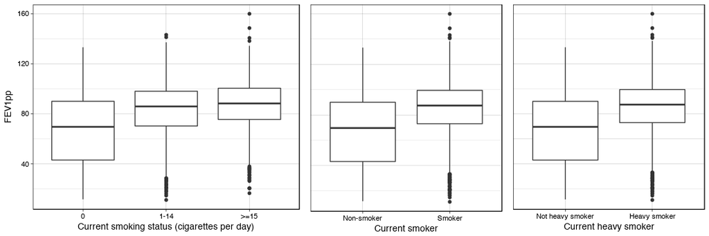

**Genetic random effects (marginal and interaction):** First, a vector $u_m$ of genetic random effects captures the variance of local ancestry that remains after taking into account the global ancestry as a fixed effect $z_g$ (Zaitlen et al. 2014). The variance-covariance matrix of $u_m$ is computed as ancestral relationship matrix (ARM) by cross-product operation on data matrix Z of ancestry segments, which previously were centered and scaled (Zaitlen et al. 2014). Any tool such as GCTA can be used to perform computation of ARM (we computed it in R). Second, another vector $u_i$ of genetic random effects complements the previous vector $u_m$ and comes out due to testing the interaction effect ($\delta_l$) rather than the main effect ($\beta_l$) (Sul et al. 2016). The variance-covariance matrix of $u_i$ is derived from ARM based on stratification by a binary environmental exposure status ($x_e$). We refer to this matrix as environmental ARM or EARM.

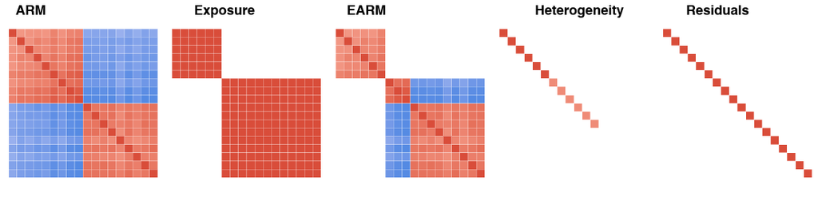

The figure above depicts the variance-covariance matrices of random effects in the model. The relationships are depicted for a subset of 18 individuals, 6 in each of three smoking groups (not current smokers; current moderate smokers; and current heavy smokers). The first 9 individuals have the largest global ancestry proportions, while the last 9 individuals have the smallest global ancestry proportions (sought for illustration purposes).

**Robustness of linear mixed model:** We showed in the manuscript that linear mixed model was robust when testing for association, and all three random effects components were essential to avoid high Type I error rate measured by inflation factor (the ratio of medians for observed and expected test statistics). For example, we reduced the inflation factor from $\lambda$ = 1.61 (none of the random effect components) to 1.06 (all three components) when testing for interactions with `FEV1pp` trait and `SmokCigNow` exposure.

**Computing association test statistic:** For each pair of trait and exposure, we fitted the linear mixed model once (omitting the variable we were testing, $z_l \times x_e$ and also $z_l$). That gave us estimates of variance components as well as the variance-covariance matrix $V$ of the trait under study, $y$. Under assumption that the $V$ matrix does not change when including $z_l$-related terms in the model, we run generalized least squares (GLS) for each association test using the $V$ matrix. This strategy is also widely used in GWAS. In practice, we run the `gaston` R package (https://cran.r-project.org/web/packages/gaston/index.html) to fit linear mixed model and the `matlm` R package (https://github.com/variani/matlm) to conduct association scan. The later package was developed by us.

## Results

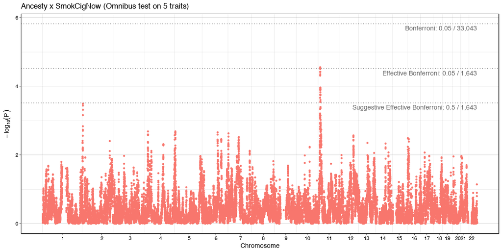

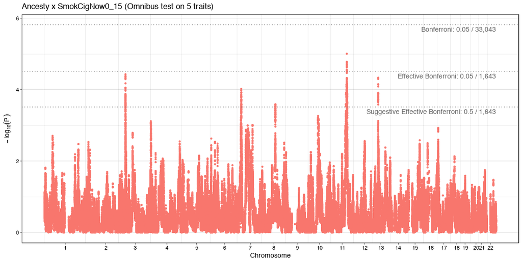

| locus | chr | start | end | exposure | mpval | top_trait | spval |
| --- | --- | --- | --- | --- | --- | --- | --- |
| 1 | 11 | 12,075,829 | 12,845,835 | SmokCigNow | 2.79e-05 | FEV1pp_utah | 5.86e-06 |
| 2 | 11 | 94,360,812 | 94,825,729 | SmokCigNow0_15 | 9.81e-06 | FEV1_utah | 2.80e-03 |

| locus | chr | start | end | exposure | mpval | top_trait | spval |
| --- | --- | --- | --- | --- | --- | --- | --- |
| 3 | 2 | 238,143,387 | 238,769,892 | SmokCigNow0_15 | 3.70e-05 | FVC_utah | 2.06e-06 |
| 4 | 13 | 31,623,839 | 32,256,475 | SmokCigNow0_15 | 4.61e-05 | FEV1_utah | 5.62e-03 |
| 5 | 7 | 25,133,849 | 26,371,279 | SmokCigNow0_15 | 9.49e-05 | FVCpp_utah | 1.73e-04 |
| 6 | 8 | 81,871,222 | 82,335,354 | SmokCigNow0_15 | 2.57e-04 | FVC_utah | 2.37e-01 |
| 7 | 1 | 248,020,448 | 249,208,153 | SmokCigNow | 3.21e-04 | FEV1_FVC_utah | 2.94e-03 |

## R code example

R code to run the admixed mapping analysis on the COPDGene dataset is available on https://gist.github.com/variani/a28c18797c39a62bacab587e6e708529.

# Admixed mapping in replication dataset

**Scenario 1:** The replication dataset is matched to the discovery COPDGene dataset in terms of smoking groups. For example, if the analysis with the current smoker exposure, only two smoking groups are included in analysis: the current non-smokers who previously had smoking history; and current smokers.

**Scenario 2:** The whole sample in the replication dataset is used in analysis.

**Important calculation steps:**

- Filter out short ancestry segments and use only long ancestry segments in analysis.
- Estimated the ARM matrix on centered and scaled local ancestry segments, as described in (Zaitlen et al. 2014).
- Derive the EARM matrix based on the exposure variable ($x_e$).
- Fit the linear mixed model to estimate the variance-covariance matrix of the trait under study ($V$).
- Run association tests using GLS, e.g. using the `matlm` R package.

# References

Aschard, Hugues, Alexander Gusev, Robert Brown, and Bogdan Pasaniuc. 2015. “Leveraging local ancestry to detect gene-gene interactions in genome-wide data.” *BMC Genetics* 16 (1). BMC Genetics: 124. doi:10.1186/s12863-015-0283-z.

Baran, Yael, Bogdan Pasaniuc, Sriram Sankararaman, Dara G. Torgerson, Christopher Gignoux, Celeste Eng, William Rodriguez-Cintron, et al. 2012. “Fast and accurate inference of local ancestry in Latino populations.” *Bioinformatics* 28 (10): 1359–67. doi:10.1093/bioinformatics/bts144.

Davis, Joe R., Laure Fresard, David A. Knowles, Mauro Pala, Carlos D. Bustamante, Alexis Battle, and Stephen B. Montgomery. 2016. “An Efficient Multiple-Testing Adjustment for eQTL Studies that Accounts for Linkage Disequilibrium between Variants.” *American Journal of Human Genetics* 98 (1). The American Society of Human Genetics: 216–24. doi:10.1016/j.ajhg.2015.11.021.

Hankinson, John L, John R Odencrantz, and Kathleen B Fedan. 1999. “Spirometric Reference Values from a Sample of the General Us Population.” *American Journal of Respiratory and Critical Care Medicine* 159 (1). Am Thoracic Soc: 179–87.

Parker, Margaret M., Marilyn G. Foreman, Haley J. Abel, Rasika A. Mathias, Jacqueline B. Hetmanski, James D. Crapo, Edwin K. Silverman, and Terri H. Beaty. 2014. “Admixture mapping identifies a quantitative trait locus associated with FEV1/FVC in the COPDGene Study.” *Genetic Epidemiology* 38 (7): 652–59. doi:10.1002/gepi.21847.

Qiu, Weiliang, Emily Wan, Jarrett Morrow, Michael H. Cho, James D. Crapo, Edwin K. Silverman, and Dawn L. DeMeo. 2015. “The impact of genetic variation and cigarette smoke on DNA methylation in current and former smokers from the COPDGene study.” *Epigenetics* 10 (11): 1064–73. doi:10.1080/15592294.2015.1106672.

Sul, Jae Hoon, Michael Bilow, Wen-Yun Yang, Emrah Kostem, Nick Furlotte, Dan He, and Eleazar Eskin. 2016. “Accounting for Population Structure in Gene-by-Environment Interactions in Genome-Wide Association Studies Using Mixed Models.” *PLoS Genetics* 12 (3): e1005849. doi:10.1371/journal.pgen.1005849.

Suzuki, Rioto, Yutaka Nakamura, Shinji Chiba, Tomoki Mizuno, Kazuyuki Abe, Yosuke Horii, Hiromi Nagashima, Tatsuo Tanita, and Kohei Yamauchi. 2016. “Mitigation of tight junction protein dysfunction in lung microvascular endothelial cells with pitavastatin.” *Pulmonary Pharmacology and Therapeutics* 38. Elsevier Ltd: 27–35. doi:10.1016/j.pupt.2016.04.003.

The LAMP-LD authors. 2017. Personal Communication.

Vestbo, Jørgen, Suzanne S Hurd, Alvar G Agustí, Paul W Jones, Claus Vogelmeier, Antonio Anzueto, Peter J Barnes, et al. 2013. “Global Strategy for the Diagnosis, Management, and Prevention of Chronic Obstructive Pulmonary Disease: GOLD Executive Summary.” *American Journal of Respiratory and Critical Care Medicine* 187 (4). Am Thoracic Soc: 347–65.

Zaitlen, Noah, Bogdan Pasaniuc, Sriram Sankararaman, Gaurav Bhatia, Jianqi Zhang, Alexander Gusev, Taylor Young, et al. 2014. “Leveraging population admixture to characterize the heritability of complex traits.” *Nature Genetics* 46 (12). Nature Publishing Group: 1356–62. doi:10.1038/ng.3139.